# SWCON253 Machine Learning

# Homework 3

**Due**: April 22, (before 11:59 pm).

**How to submit**

You need to send the `.ipynb` file with your answers plus an `.html` file, which will serve as a backup for us in case the `.ipynb` file cannot be opened on my or the TA's computer.

The homework solution should be uploaded on e-campus. You can submit it as often as you like before the deadline.

**Important**

- Please make sure that you provide an answer in each cell and place that contains the **[ your answer ]** tags.
- The places that require your code answer are marked with `"# YOUR CODE"` comments.
- Note that you may use 1 or more line of code for replacing each `"# YOUR CODE"` comment.

For example, imagine there is a question asking you to implement a threshold function that should return 1 if the input `x` is greater than 0.5 and otherwise. This could appear as follows in the the exercise:

```
def threshold_func(x):
    # YOUR CODE
```

A valid answer could be

```
def threshold_func(x):
    if x > 0.5:
        return 1
    else:
        return 0
```

Another valid solution could be

```
def threshold_func(x):
    return int(x > 0.5)
```

```python
%load_ext watermark
%watermark  -d -u -a "BoMin Seo" -v -p numpy,scipy,matplotlib,sklearn
```

```
Author: BoMin Seo

Last updated: 2021-04-16

Python implementation: CPython
Python version       : 3.9.2
IPython version      : 7.22.0

numpy     : 1.20.2
scipy     : 1.6.2
matplotlib: 3.4.1
sklearn   : 0.0
```

The watermark package that is being used in the next code cell provides a helper function of the same name, `%watermark` for showing information about your computational environment. This is useful for keeping track of what software versions are/were being used. If you encounter issues with the code, please make sure that your software package have the same version as the the ones shown in the pre-executed watermark cell.

Before you execute the watermark cell, you need to install watermark first. If you have not done this yet. To install the watermark package, simply run

```
!pip install watermark
```

or

```
!conda install watermark -c conda-forge
```

in the a new code cell. Alternatively, you can run either of the two commands (the latter only if you have installed Anaconda or Miniconda) in your command line terminal (e.g., a Linux shell, the Terminal app on macOS, or Cygwin, Putty, etc. on Windows).

For more information installing Python, please refer to the previous lectures and ask the TA for help.

## E 1) [10 pts]

Import the NumPy library to create a 3x3 matrix with values ranging 0-8. The expected output should look as follows:

[output not shown]

```python
import numpy as np

A = np.array([[0,1,2],[3,4,5],[6,7,8]])
A
```

```
array([[0, 1, 2],
       [3, 4, 5],
       [6, 7, 8]])
```

## E 2) [10 pts]

Use create a 2x2 NumPy array with random values drawn from a uniform distribution using the random seed `123` and show the results below.

```python
rng = np.random.RandomState(123)
rng.uniform(0.0,1.0,4).reshape(2,2)
```

```
array([[0.69646919, 0.28613933],
       [0.22685145, 0.55131477]])
```

## E 3) [10 pts]

Given an array `A`,

```
array([[ 1,  2,  3,  4],
       [ 5,  6,  7,  8],
       [ 9, 10, 11, 12],
       [13, 14, 15, 16]])
```

use the NumPy slicing syntax to only select the 2x2 lower-right corner of this matrix.

```python
A = np.array([
    [1, 2, 3, 4],
    [5, 6, 7, 8],
    [9, 10, 11, 12],
    [13, 14, 15, 16]])

A[-2:,-2:]
```

```
array([[11, 12],
       [15, 16]])
```

## E 4) [10 pts]

Given the array `A` below, find the least frequent integer in that array:

```python
rng = np.random.RandomState(123)
A = rng.randint(0, 10, 200)
counts = np.bincount(A)
```

```python
np.argmin(counts)
```

```
5
```

## E 5) [10 pts]

Complete the line of code below to read in the `'train_data.txt'` dataset, which consists of 3 columns: 2 feature columns and 1 class label column. The columns are separated via commas and show the first 5 lines of the DataFrame.

```python
import pandas as pd

df_train = pd.read_csv('train_data.txt',sep = ',')
df_train.head()
```

|  | x1 | x2 | y |
| --- | --- | --- | --- |
| 0 | -3.84 | -4.40 | 0 |
| 1 | 16.36 | 6.54 | 1 |
| 2 | -2.73 | -5.13 | 0 |
| 3 | 4.83 | 7.22 | 1 |
| 4 | 3.66 | -5.34 | 0 |

## E 6) [10 pts]

Consider the following code below, which plots one the samples from class 0 in a 2D scatterplot using matplotlib:

```python
X_train = df_train[['x1', 'x2']].values
y_train = df_train['y'].values
```

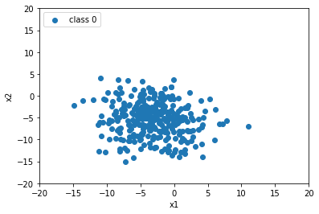

```python
%matplotlib inline
import matplotlib.pyplot as plt


plt.scatter(X_train[y_train == 0, 0],
            X_train[y_train == 0, 1],
            label='class 0',)

plt.xlabel('x1')
plt.ylabel('x2')
plt.xlim([-20, 20])
plt.ylim([-20, 20])
plt.legend(loc='upper left')
plt.show()
```

Now, the following code below is identical to the code in the previous code cell but contains partial code to also include the examples from the second class. Complete the second `plt.scatter` function to also plot the training examples from `class 1`.

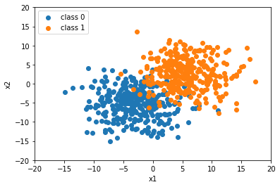

```python
plt.scatter(X_train[y_train == 0, 0],
            X_train[y_train == 0, 1],
            label='class 0',)

plt.scatter(X_train[y_train == 1, 0],
            X_train[y_train == 1, 1],
            label='class 1',)

plt.xlabel('x1')
plt.ylabel('x2')
plt.xlim([-20, 20])
plt.ylim([-20, 20])
plt.legend(loc='upper left')
plt.show()
```

## E 7) [10 pts]

Consider the we trained a 3-nearest neighbor classifier using scikit-learn on the previous training dataset:

```python
from sklearn.neighbors import KNeighborsClassifier

knn = KNeighborsClassifier(n_neighbors=3)
knn.fit(X_train, y_train)
```

```
KNeighborsClassifier(n_neighbors=3)
```

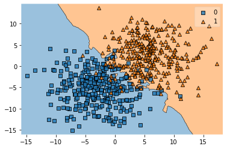

```python
from mlxtend.plotting import plot_decision_regions

plot_decision_regions(X_train, y_train, knn)
```

Compute *the number of* misclassifications of the 3-NN classifier on the training set. The number of errors should be a count, i.e., a positive integer.

```python
errors = int(len(y_train) - knn.score(X_train, y_train) *len(y_train))
errors
```

```
33
```

## E 8) [10 pts]

Use the code from E 7) to

- also visualize the decision boundaries of *k*-nearest neighbor classifiers with k=1, k=5, k=7, k=9
- compute the prediction error on the training set for the *k*-nearest neighbor classifiers with k=1, k=5, k=7, k=9

```
Errors: 0
```

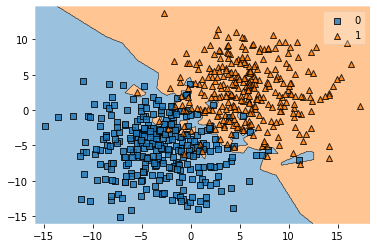

```python
knn = KNeighborsClassifier(n_neighbors=1)
knn.fit(X_train, y_train)
plot_decision_regions(X_train, y_train, knn)
errors = int(len(y_train) - knn.score(X_train, y_train) *len(y_train))
print('Errors:', errors)
```

```
Errors: 32
```

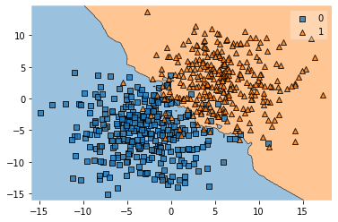

```python
knn = KNeighborsClassifier(n_neighbors=5)
knn.fit(X_train, y_train)
plot_decision_regions(X_train, y_train, knn)
errors = int(len(y_train) - knn.score(X_train, y_train) *len(y_train))
print('Errors:', errors)
```

```
Errors: 29
```

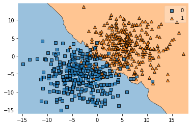

```python
knn = KNeighborsClassifier(n_neighbors=7)
knn.fit(X_train, y_train)
plot_decision_regions(X_train, y_train, knn)
errors = int(len(y_train) - knn.score(X_train, y_train) *len(y_train))
print('Errors:', errors)
```

```
Errors: 30
```

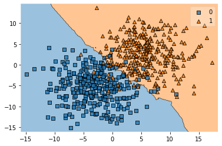

```python
knn = KNeighborsClassifier(n_neighbors=9)
knn.fit(X_train, y_train)
plot_decision_regions(X_train, y_train, knn)
errors = int(len(y_train) - knn.score(X_train, y_train) *len(y_train))
print('Errors:', errors)
```

## E 9) [5 pts]

Using a similar approach you used in E 5), now load the `test_data.txt` file into a pandas array. However, note that the dataset now has whitespaces separating the columns instead of commas.

```python
df_test = pd.read_csv('test_data.txt',sep = " ")

df_test.head()
```

|  | x1 | x2 | y |
| --- | --- | --- | --- |
| 0 | -5.75 | -6.83 | 0 |
| 1 | 5.51 | 3.67 | 1 |
| 2 | 5.11 | 5.32 | 1 |
| 3 | 0.85 | -4.11 | 0 |
| 4 | -0.50 | -0.45 | 1 |

```python
X_test = df_test[['x1', 'x2']].values
y_test = df_test['y'].values
```

## E 10) [10 pts]

Use the `train_test_split` function from scikit-learn to divide the training dataset further into a training subset and a validation set. The validation set should be 20% of the training dataset size, and the training subset should be 80% of the training dataset size.

For you reference, the `train_test_split` function is documented at http://scikit-learn.org/stable/modules/generated/sklearn.model_selection.train_test_split.html.

```python
from sklearn.model_selection import train_test_split


X_train_sub, X_val, y_train_sub, y_val = train_test_split(X_train, y_train,
                                                          test_size=0.2,
                                                          random_state =123,
                                                          stratify=y_train)
```

## E 11) [10 pts]

Write a for loop to evaluate different *k* nn models with k=1 to k=14. In particular, fit the `KNeighborsClassifier` on the training subset, then evaluate it on the training subset, validation subset, and test subset. Report the respective classification error or accuracy.

```python
df_test = pd.read_csv('test_data.txt',sep = " ")
X_test = df_test[['x1', 'x2']].values
y_test = df_test['y'].values


for k in range(1, 15):
    knn = KNeighborsClassifier(n_neighbors=k)
    knn.fit(X_train_sub, y_train_sub)
    y_pred = knn.predict(X_test)
    num_correct_predictions = (y_pred == y_test).sum()
    accuracy1 = knn.score(X_train_sub,y_train_sub) * 100
    accuracy2 = knn.score(X_val,y_val) * 100
    accuracy3 = (num_correct_predictions / y_test.shape[0]) * 100
    print("k = ",k,f'Train set accuracy: {accuracy1:.2f}%',f'Val set accuracy: {accuracy2:.2f}%',f'Test set accuracy: {accuracy3:.2f}%')
```

```
k =  1 Train set accuracy: 100.00% Val set accuracy: 88.33% Test set accuracy: 91.50%
k =  2 Train set accuracy: 96.04% Val set accuracy: 90.00% Test set accuracy: 92.00%
k =  3 Train set accuracy: 95.42% Val set accuracy: 90.83% Test set accuracy: 94.00%
k =  4 Train set accuracy: 95.83% Val set accuracy: 90.83% Test set accuracy: 95.00%
k =  5 Train set accuracy: 96.25% Val set accuracy: 90.83% Test set accuracy: 95.50%
k =  6 Train set accuracy: 96.46% Val set accuracy: 91.67% Test set accuracy: 95.00%
k =  7 Train set accuracy: 95.42% Val set accuracy: 92.50% Test set accuracy: 94.50%
k =  8 Train set accuracy: 95.42% Val set accuracy: 93.33% Test set accuracy: 94.50%
k =  9 Train set accuracy: 94.58% Val set accuracy: 92.50% Test set accuracy: 95.50%
k =  10 Train set accuracy: 94.79% Val set accuracy: 92.50% Test set accuracy: 96.00%
k =  11 Train set accuracy: 94.79% Val set accuracy: 92.50% Test set accuracy: 95.50%
k =  12 Train set accuracy: 94.79% Val set accuracy: 92.50% Test set accuracy: 96.00%
k =  13 Train set accuracy: 94.38% Val set accuracy: 92.50% Test set accuracy: 95.00%
k =  14 Train set accuracy: 94.17% Val set accuracy: 92.50% Test set accuracy: 95.50%
```